# Clustering Exercise: Customer Segmentation, Solution

MKT 566 · Decision Making Using Marketing Analytics · Fall 2026

The same exercise as the handout, with one possible set of answers. Every number in the answers comes from the table or chart right above it.

## The data

One row per **customer** of a retailer that sells both online and in its stores. Columns:

| Column | What it is |
| --- | --- |
| `CustomerID` | the customer |
| `Age` | age in years |
| `Income` | annual income, in dollars |
| `Online_Spend` | dollars the customer spent online last year |
| `InStore_Spend` | dollars the customer spent in the stores last year |

The retailer wants to know **what kinds of customers it has**, and what to do with each kind. There is no outcome to predict: this is k-means and PCA, as in Tuesday’s slides.

## Task 1: look at the data

```r
# load the data (the file must be in the same folder as this Rmd)
df <- fread("customer_clustering_data.csv")

# the first rows of the data
knitr::kable(head(df), format.args = list(big.mark = ","))
```

| CustomerID | Age | Income | Online_Spend | InStore_Spend |
| --- | --- | --- | --- | --- |
| 1 | 23 | 37,241 | 1,212 | 239 |
| 2 | 24 | 35,265 | 1,073 | 181 |
| 3 | 31 | 39,611 | 584 | 520 |
| 4 | 25 | 45,250 | 1,539 | 431 |
| 5 | 26 | 32,545 | 762 | 273 |
| 6 | 32 | 23,454 | 1,422 | 354 |

```r
# a summary of the four numeric columns: smallest, middle, average, largest
num <- df[, .(Age, Income, Online_Spend, InStore_Spend)]
knitr::kable(data.table(Column   = names(num),
                        Smallest = sapply(num, min),
                        Median   = round(sapply(num, median)),
                        Average  = round(sapply(num, mean)),
                        Largest  = sapply(num, max)),
             format.args = list(big.mark = ","))
```

| Column | Smallest | Median | Average | Largest |
| --- | --- | --- | --- | --- |
| Age | 17 | 34 | 35 | 59 |
| Income | 23,454 | 58,478 | 57,681 | 105,041 |
| Online_Spend | 1 | 1,088 | 1,169 | 3,475 |
| InStore_Spend | 147 | 1,938 | 1,617 | 3,615 |

- How many customers are there, and what does one row describe?
- Look at the ranges of the four columns. Which column has by far the largest numbers? Why does that matter for k-means? (Tuesday’s “Watch the units” slide.)

**Answer:** 198 customers, one row each. Age runs from 17 to 59, income from $23,454 to $105,041, online spend from $1 to $3,475, and in-store spend from $147 to $3,615. **Income** has numbers dozens of times larger than the spend columns and more than a thousand times larger than age. K-means groups customers by distance, so two customers $10,000 apart in income would count as 10,000 “units” apart, while two customers 30 years apart in age would be only 30 apart. Left alone, income would decide the clusters.

## Task 2: a first picture

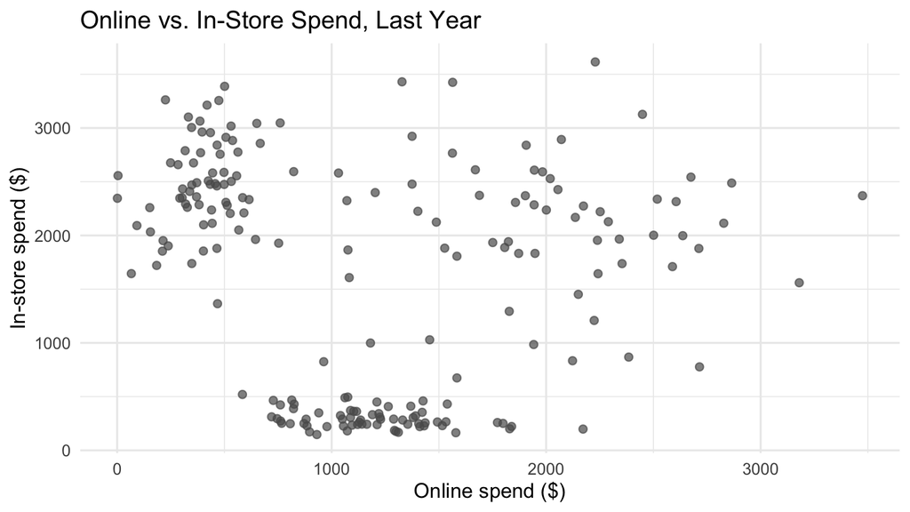

```r
ggplot(df, aes(x = Online_Spend, y = InStore_Spend)) +
  geom_point(size = 2, alpha = 0.7, color = "grey35") +
  labs(title = "Online vs. In-Store Spend, Last Year",
       x = "Online spend ($)", y = "In-store spend ($)") +
  theme_minimal(base_size = 13)
```

- How many groups do you see? Describe each one in words.

**Answer:** Three. Top left, customers who spend a lot in the stores and little online. Bottom, customers who spend mostly online and little in the stores. Top right, customers who spend a lot in both channels. The two upper groups touch, so the borders are not perfectly sharp.

## Task 3: standardize, then choose k

```r
# the four columns we cluster on
feat <- df[, .(Online_Spend, InStore_Spend, Age, Income)]

# standardize: each column becomes (value - its mean) / its standard deviation
X <- scale(feat)
knitr::kable(round(head(X), 2))
```

| Online_Spend | InStore_Spend | Age | Income |
| --- | --- | --- | --- |
| 0.06 | -1.31 | -1.25 | -1.02 |
| -0.13 | -1.37 | -1.15 | -1.12 |
| -0.79 | -1.04 | -0.44 | -0.90 |
| 0.50 | -1.13 | -1.05 | -0.62 |
| -0.55 | -1.28 | -0.95 | -1.26 |
| 0.34 | -1.20 | -0.34 | -1.71 |

```r
# elbow curve: run k-means for k = 2 to 10 and record the within-cluster spread
set.seed(123)
wss <- sapply(2:10, function(k) kmeans(X, centers = k, nstart = 20)$tot.withinss)
elbow <- data.table(k = 2:10, wss = round(wss, 1))
knitr::kable(elbow, col.names = c("k", "Within-cluster spread"))
```

| k | Within-cluster spread |
| --- | --- |
| 2 | 399.0 |
| 3 | 180.8 |
| 4 | 153.8 |
| 5 | 137.3 |
| 6 | 126.8 |
| 7 | 112.5 |
| 8 | 104.8 |
| 9 | 99.4 |
| 10 | 93.3 |

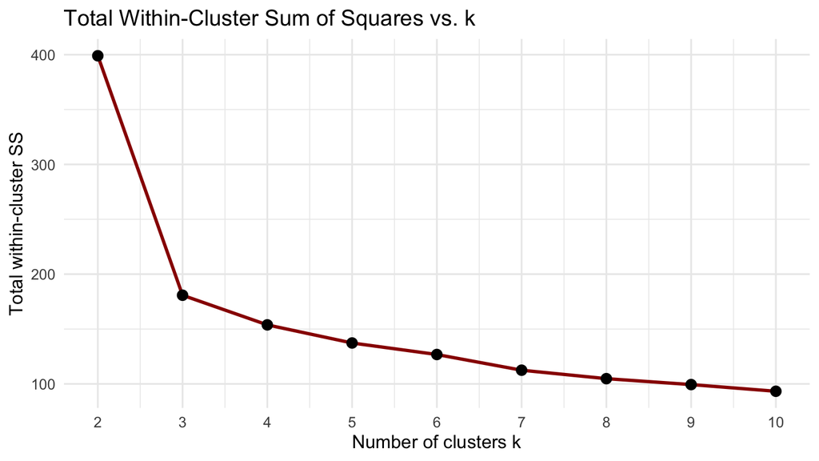

```r
ggplot(elbow, aes(x = k, y = wss)) +
  geom_line(color = "#990000", linewidth = 1.1) +
  geom_point(size = 3) +
  scale_x_continuous(breaks = 2:10) +
  labs(title = "Total Within-Cluster Sum of Squares vs. k",
       x = "Number of clusters k", y = "Total within-cluster SS") +
  theme_minimal(base_size = 13)
```

- After `scale()`, what does a value of 0 in `X` mean? And a value of 1?
- Where is the elbow? Propose a k, with the numbers from the elbow table.

**Answer:** A 0 is exactly the average customer on that column; a 1 is one standard deviation above the average ($19,976 for income, 10 years for age). Every column is now on the same footing. Going from 2 to 3 clusters cuts the within-cluster spread from **399 to 181**; going from 3 to 4 cuts it only to 154. The curve bends at **k = 3**, which also matches the three groups we saw in Task 2.

## Task 4: k-means with k = 3, and the profile table

```r
# k-means on the standardized columns; nstart = 20 tries 20 random starts
set.seed(123)
km <- kmeans(X, centers = 3, nstart = 20)
df[, cluster := factor(km$cluster)]

# profile each cluster in the ORIGINAL units (dollars, years)
profile <- df[, .(customers     = .N,
                  online_spend  = round(mean(Online_Spend)),
                  instore_spend = round(mean(InStore_Spend)),
                  total_spend   = round(mean(Online_Spend + InStore_Spend)),
                  age           = round(mean(Age), 1),
                  income        = round(mean(Income)),
                  total_all     = sum(Online_Spend + InStore_Spend)),
              keyby = cluster]
# each cluster's share of all the money customers spent
profile[, share_of_spend_pct := round(100 * total_all / sum(total_all), 1)]
profile[, total_all := NULL]
knitr::kable(profile, format.args = list(big.mark = ","),
             col.names = c("Cluster", "Customers", "Online spend (dollars)",
                           "In-store spend (dollars)", "Total spend (dollars)", "Age",
                           "Income (dollars)", "Share of all spend (%)"))
```

| Cluster | Customers | Online spend (dollars) | In-store spend (dollars) | Total spend (dollars) | Age | Income (dollars) | Share of all spend (%) |
| --- | --- | --- | --- | --- | --- | --- | --- |
| 1 | 68 | 418 | 2,453 | 2,871 | 45.9 | 59,542 | 35.4 |
| 2 | 67 | 1,185 | 306 | 1,491 | 25.1 | 35,594 | 18.1 |
| 3 | 63 | 1,964 | 2,110 | 4,074 | 34.9 | 79,161 | 46.5 |

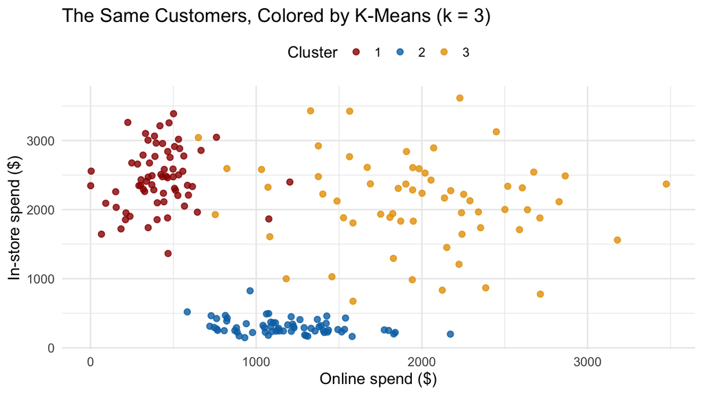

```r
ggplot(df, aes(x = Online_Spend, y = InStore_Spend, color = cluster)) +
  geom_point(size = 2, alpha = 0.8) +
  scale_color_manual(values = c("1" = "#990000", "2" = "#0072B2", "3" = "#E69F00")) +
  labs(title = "The Same Customers, Colored by K-Means (k = 3)",
       x = "Online spend ($)", y = "In-store spend ($)", color = "Cluster") +
  theme_minimal(base_size = 13) +
  theme(legend.position = "top")
```

- Describe each cluster with the numbers from the profile table, and give each one a name a marketer would use.
- Why is the profile table computed on the original columns (`df`) and not on the standardized ones (`X`)?

**Answer:** Cluster 1, **in-store loyalists**: 68 customers who spend $2,453 in the stores and only $418 online; the oldest group (46 on average), income $59,542. Cluster 2, **young online shoppers**: 67 customers who spend $1,185 online and $306 in the stores; age 25, income $35,594, the lowest. Cluster 3, **omni-channel big spenders**: 63 customers who spend about $2,000 in each channel, $4,074 in total; age 35, the highest income at $79,161. The profile uses the original columns because “$2,453 in the stores” means something to a manager, and “1.2 standard deviations above average” does not.

## Task 5: what if we had not standardized?

```r
# the same k-means, on the raw columns (no scale())
set.seed(123)
km_raw <- kmeans(feat, centers = 3, nstart = 20)
df[, cluster_raw := factor(km_raw$cluster)]

raw_profile <- df[, .(customers     = .N,
                      online_spend  = round(mean(Online_Spend)),
                      instore_spend = round(mean(InStore_Spend)),
                      age           = round(mean(Age), 1),
                      income        = round(mean(Income))),
                  keyby = cluster_raw]
knitr::kable(raw_profile, format.args = list(big.mark = ","),
             col.names = c("Raw cluster", "Customers", "Online spend (dollars)",
                           "In-store spend (dollars)", "Age", "Income (dollars)"))
```

| Raw cluster | Customers | Online spend (dollars) | In-store spend (dollars) | Age | Income (dollars) |
| --- | --- | --- | --- | --- | --- |
| 1 | 79 | 777 | 2,361 | 42.8 | 61,931 |
| 2 | 45 | 1,920 | 2,099 | 35.8 | 85,681 |
| 3 | 74 | 1,132 | 530 | 27.2 | 36,117 |

```r
# where did each customer go? Rows: the raw clusters from this task.
# Columns: the standardized clusters from Task 4. Each cell counts the
# customers who are in both.
where <- as.data.frame.matrix(table(df$cluster_raw, df$cluster))
colnames(where) <- paste("Task 4 cluster", colnames(where))
rownames(where) <- paste("Raw cluster", rownames(where))
knitr::kable(where, align = "c",
             caption = "Number of customers in each raw cluster (rows) and each Task 4 cluster (columns)")
```

Number of customers in each raw cluster (rows) and each Task 4 cluster (columns)

|  | Task 4 cluster 1 | Task 4 cluster 2 | Task 4 cluster 3 |
| --- | --- | --- | --- |
| Raw cluster 1 | 59 | 1 | 19 |
| Raw cluster 2 | 2 | 0 | 43 |
| Raw cluster 3 | 7 | 66 | 1 |

- What separates the three raw clusters? Look at the income column.
- Use the last table (where each customer went): which Task 4 cluster gets split or mixed up? Which clustering would you hand to the marketing team?

**Answer:** The raw clusters are **income bands**: average incomes of $36,117, $61,931, and $85,681. Income has the biggest numbers, so it dominates the distance, exactly as Task 1 warned. The spend patterns get blurred: raw cluster 1 mixes 59 in-store loyalists with 19 omni-channel spenders, and raw cluster 3 is mostly the young online shoppers (66) plus 8 others. Only the standardized version recovers the three groups we can see in Task 2, so that is the one for the marketing team.

## Task 6: the PCA map

```r
# PCA on the four columns, standardized inside prcomp()
pca <- prcomp(feat, center = TRUE, scale. = TRUE)
knitr::kable(round(summary(pca)$importance, 2))
```

|  | PC1 | PC2 | PC3 | PC4 |
| --- | --- | --- | --- | --- |
| Standard deviation | 1.49 | 1.16 | 0.50 | 0.42 |
| Proportion of Variance | 0.56 | 0.34 | 0.06 | 0.04 |
| Cumulative Proportion | 0.56 | 0.89 | 0.96 | 1.00 |

```r
# loadings: how much each column counts in PC1 and PC2
knitr::kable(round(pca$rotation[, 1:2], 2))
```

|  | PC1 | PC2 |
| --- | --- | --- |
| Online_Spend | -0.13 | -0.81 |
| InStore_Spend | 0.63 | -0.02 |
| Age | 0.58 | 0.28 |
| Income | 0.50 | -0.51 |

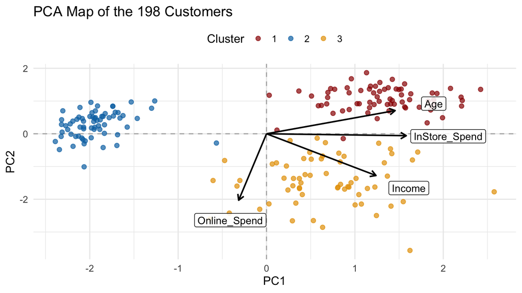

```r
# the map: every customer at its (PC1, PC2), colored by cluster, plus the arrows
scores   <- data.table(pca$x[, 1:2], cluster = df$cluster)
loadings <- data.table(pca$rotation[, 1:2], variable = rownames(pca$rotation))
arrow_scale <- 2.5

ggplot() +
  geom_hline(yintercept = 0, linetype = "dashed", color = "grey70") +
  geom_vline(xintercept = 0, linetype = "dashed", color = "grey70") +
  geom_point(data = scores, aes(x = PC1, y = PC2, color = cluster),
             size = 2, alpha = 0.7) +
  geom_segment(data = loadings,
               aes(x = 0, y = 0, xend = PC1 * arrow_scale, yend = PC2 * arrow_scale),
               arrow = arrow(length = unit(0.25, "cm")), linewidth = 0.8) +
  geom_label(data = loadings,
             aes(x = PC1 * arrow_scale * 1.3, y = PC2 * arrow_scale * 1.3,
                 label = variable), size = 4, fill = "white", alpha = 0.85) +
  scale_color_manual(values = c("1" = "#990000", "2" = "#0072B2", "3" = "#E69F00")) +
  labs(title = "PCA Map of the 198 Customers",
       x = "PC1", y = "PC2", color = "Cluster") +
  theme_minimal(base_size = 13) +
  theme(legend.position = "top")
```

- How much of the variation do PC1 and PC2 keep together? (The “Cumulative Proportion” row of the first table.)
- Read the loadings: what does it mean to move **right** on PC1? To move **down** on PC2? (PCA picks the direction of each axis arbitrarily; only the arrows tell you what the axes mean.)
- Where does each cluster sit on the map? Do they separate?

**Answer:** Together they keep **89%** of the variation (PC1 56%, PC2 34%), so this two-axis map is almost the whole story. PC1 loads on in-store spend (0.63), age (0.58), and income (0.50): moving right means **older, richer, and spending more in the stores**. PC2 loads negatively on online spend (-0.81) and income (-0.51): moving **down** means **more online spend and more income**. The young online shoppers sit on the left; the in-store loyalists on the right and up; the omni-channel spenders on the right and down, next to the online-spend arrow. Three clean clouds, the same three groups as Task 4.

## Task 7: the recommendation

- Which segment is the most valuable: per customer, and in total? Use the profile table from Task 4.
- Propose **one marketing action per segment**: which channel, which offer, which message.
- State **one limitation** of this analysis for those decisions.

**Answer:** The **omni-channel big spenders** are the most valuable on both counts: $4,074 per customer, and 46.5% of all the money spent by 32% of the customers. Actions: (1) omni-channel: protect them with a loyalty program that works across channels (points earned online, spent in store; early access); (2) in-store loyalists: in-store service and events, plus an easy first step online such as buy online, pick up in store; (3) young online shoppers: mobile and social promotions, free-shipping thresholds that raise the basket; they spend the least today but have the longest customer lifetime ahead. Limitation: the clusters **describe** customers, they do not explain them. Nothing here says that moving a loyalist online would raise their spending; that needs an experiment. Also, k = 3 is a choice, and spend is one year of history.